# Pneumolysin

Fold-switch pair **5ly6B_5aoeB** — **5ly6B** vs **5aoeB**

Streptococcus pneumoniae D39 / Streptococcus pneumoniae

## Figure 1: Phylogenetic tree with per-cluster fold-preference heatmap.

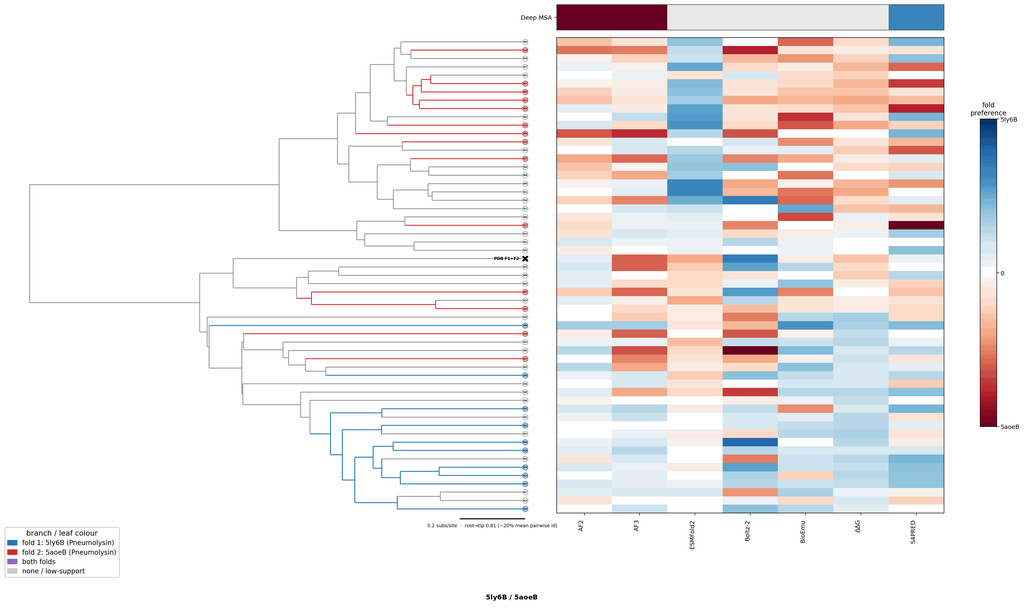

## Figure 2: Aligned overlay (both folds superposed)

The single fold-switching chain of each fold superposed by TM-align; waters hidden, any ligand shown as green sticks. Grey = structurally conserved core, colour = divergent (fold-switching) region. This pair switches fold coupled to oligomerisation; a single protomer is shown, not the full assembly.

5ly6B (Pneumolysin) · monomer5aoeB (Pneumolysin) · dimer

TM-score: 0.478 · Trigger class: oligomerization

Aligned overlay

## Figure 3: The two folds, side by side

Each fold is coloured by per-residue Cα deviation between the two superposed structures: grey ≈ conserved core, full colour = structurally divergent (fold-switching) region.

5ly6B (Pneumolysin)

5aoeB (Pneumolysin)

0 Å5≥10 Å

5ly6B (Pneumolysin)

5aoeB (Pneumolysin)

## Figure 4: Best-cluster predicted contact maps over the two true folds.

Predicted contact maps (MSA-Transformer) for the clusters best matching each fold, over the true contacts of fold 1 (upper triangle) and fold 2 (lower). Divergent contacts between clusters are the contact-level signature of fold-switching.

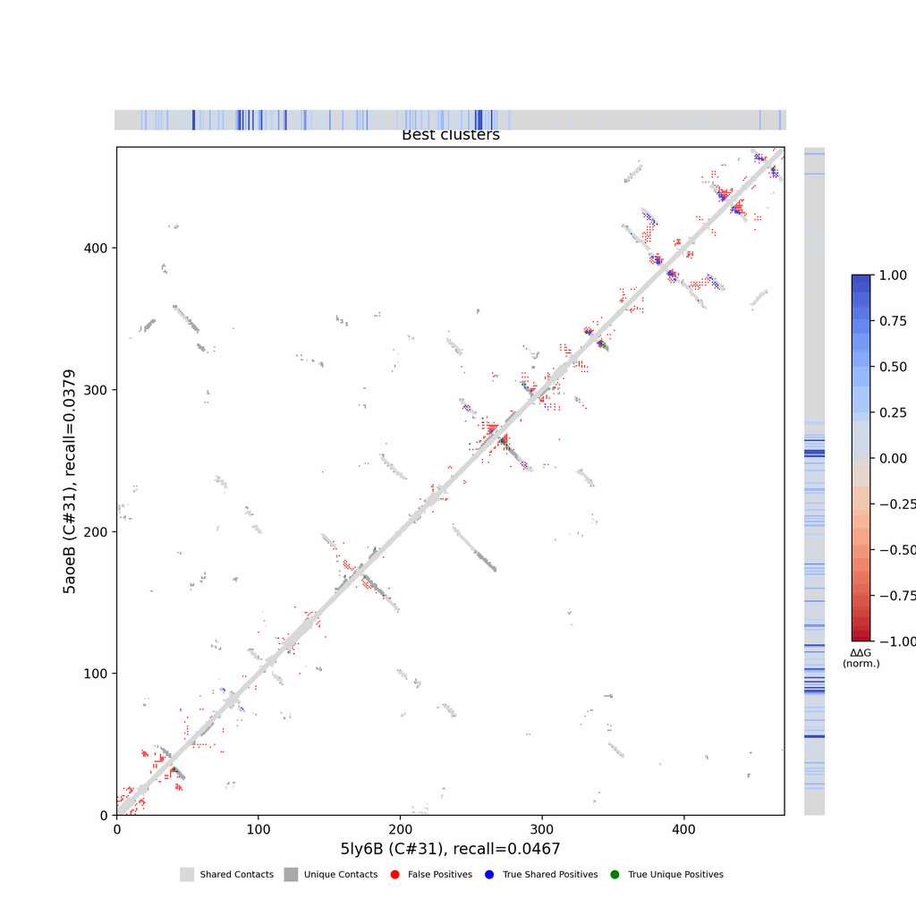

## Figure 5: Per-residue ΔΔG fold-preference contribution

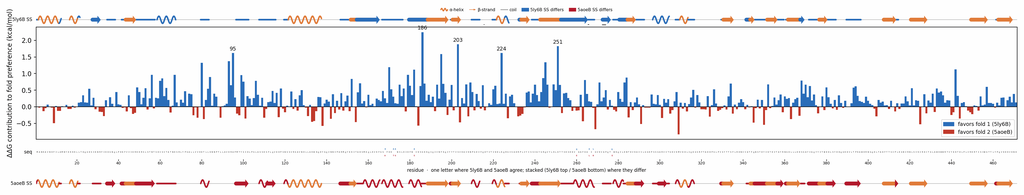

**More figures**

## Figure 6: Deep-MSA contact map panel / Best clusters contact map panel

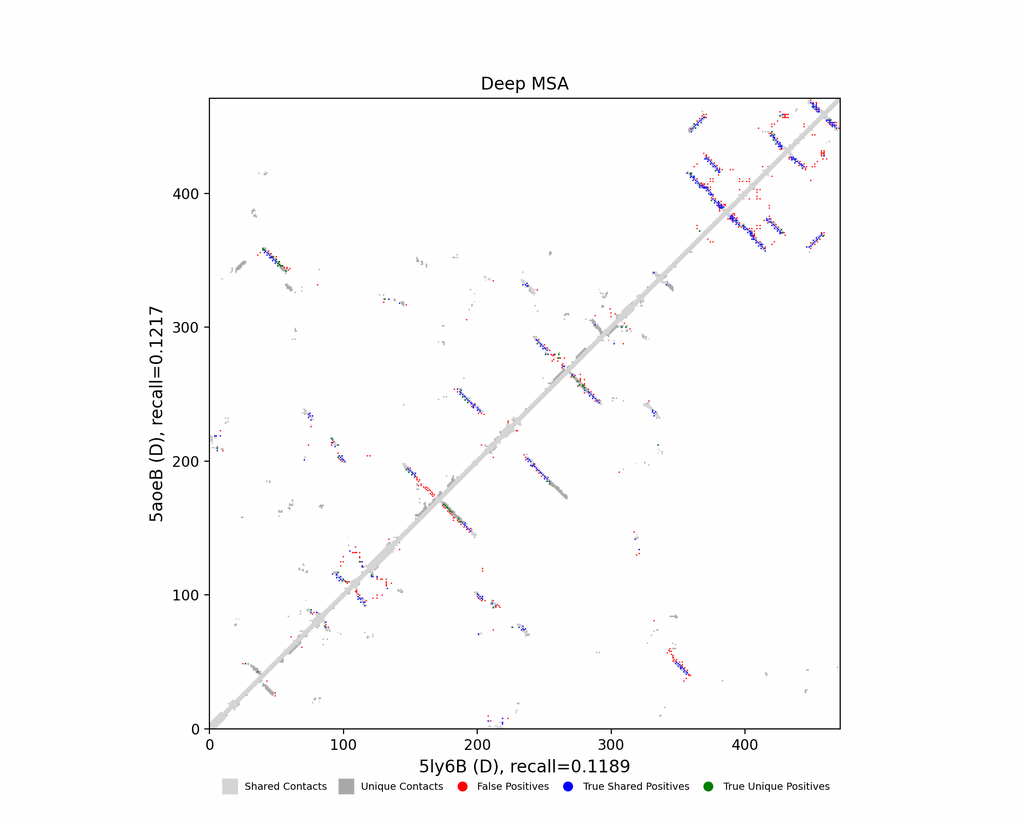

Deep-MSA contact map panel

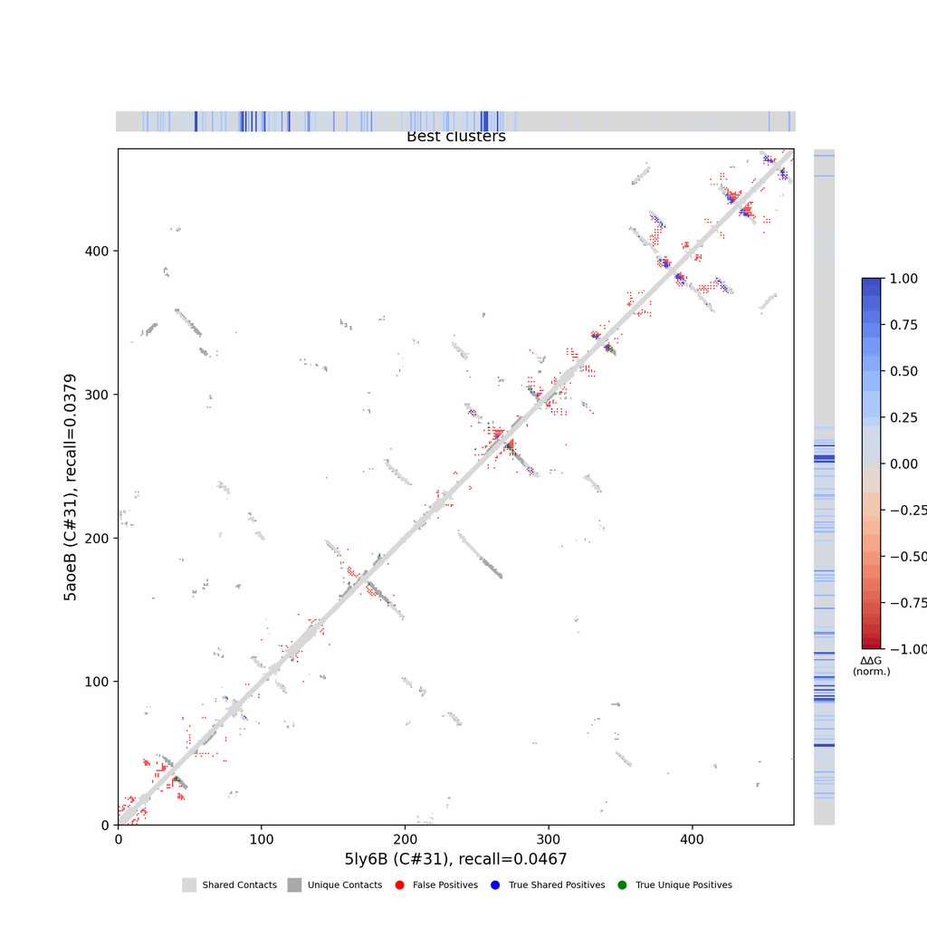

Best clusters contact map panel

## Figure 7: All clusters contact-map mosaic (small multiples).

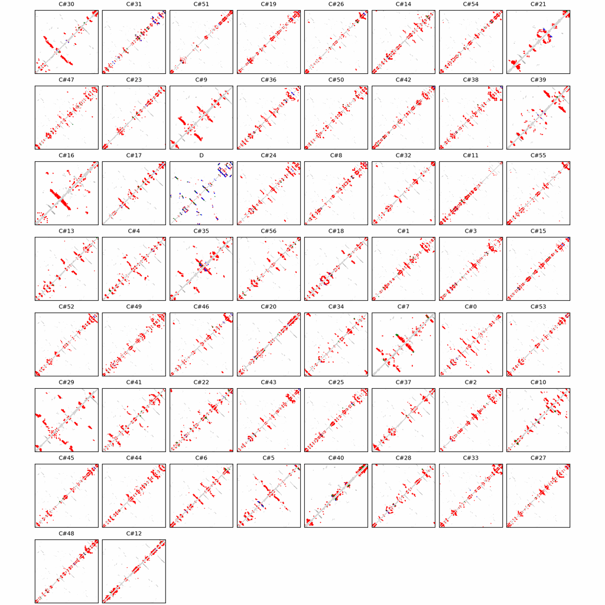

## Figure 8: Phylo null: tree with shuffled cluster fold labels.

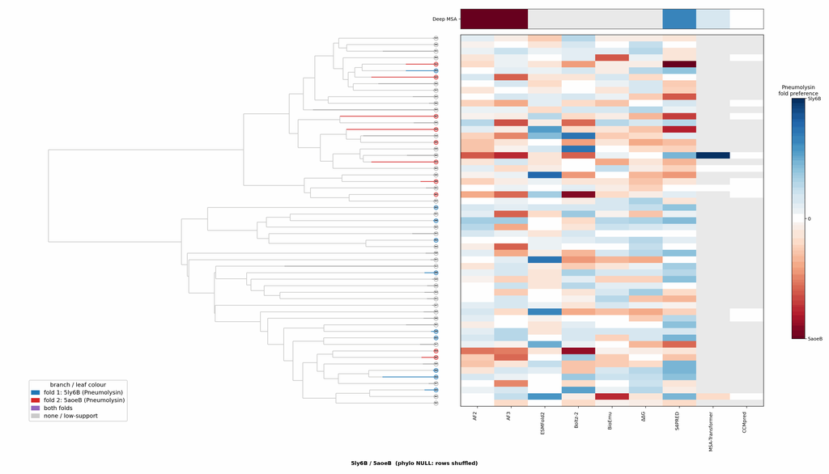

## Cluster metrics table

Per-cluster metrics underlying the figures above.

| cluster | n | neff | AF2_TM1 | AF2_TM2 | AF3_TM1 | AF3_TM2 | RE-MSAT-COM | RE-MSAT1 | RE-MSAT2 | ESM_SEQIDS | ESM_TM1 | ESM_TM2 | ΔΔG_Bias | ΔΔG_Bias_std | ΔΔG_frac_F1 | Boltz2_pref | S4PRED_pref | CCMpred_pref | BioEmu_pref |
| --- | --- | --- | --- | --- | --- | --- | --- | --- | --- | --- | --- | --- | --- | --- | --- | --- | --- | --- | --- |
| Deep | - | - | 0.48 | 0.8 | 0.48 | 0.88 | 0.42 | 0.37 | 0.38 | - | - | - | - | - | - | - | 0.04 | 0.0 | - |
| 000 | 77.0 | 45.0 | 0.46 | 0.67 | 0.48 | 0.83 | 0.0 | 0.0 | 0.0 | 001; 007; 007; 001; 005; 004; 004; 005; 009; 009 | 0.46 ± 0.01 | 0.74 ± 0.05 | 81.06 | 28.08 | 1.0 | -0.03 | 0.05 | 0.0 | -0.01 |
| 001 | 46.0 | 12.0 | 0.21 | 0.23 | 0.26 | 0.29 | 0.0 | 0.0 | 0.0 | 001; 007; 007; 006; 010; 001; 006; 010; 002; 002 | 0.47 ± 0.00 | 0.75 ± 0.03 | 55.22 | 22.54 | 1.0 | 0.01 | 0.02 | 0.0 | -0.02 |
| 002 | 35.0 | 10.0 | 0.18 | 0.19 | 0.21 | 0.18 | 0.0 | 0.0 | 0.0 | 008; 003; 004; 004; 003; 008; 001; 001; 002; 002 | 0.28 ± 0.02 | 0.37 ± 0.06 | 70.23 | 31.18 | 1.0 | -0.01 | 0.05 | 0.0 | -0.04 |
| 003 | - | - | 0.22 | 0.2 | 0.43 | 0.55 | 0.0 | 0.0 | 0.0 | 001; 006; 007; 006; 007; 001; 005; 003; 004; 005 | 0.46 ± 0.00 | 0.67 ± 0.02 | 77.04 | 8.1 | 1.0 | 0.0 | 0.01 | 0.0 | 0.0 |
| 004 | 25.0 | 7.0 | 0.16 | 0.22 | 0.39 | 0.43 | 0.0 | 0.0 | 0.04 | - | - | - | 91.06 | 7.11 | 1.0 | 0.0 | 0.02 | 0.0 | -0.04 |
| 005 | 24.0 | 6.0 | 0.43 | 0.57 | 0.47 | 0.76 | 0.06 | 0.06 | 0.05 | - | - | - | 75.36 | 22.06 | 1.0 | -0.02 | 0.03 | 0.0 | -0.03 |
| 006 | 24.0 | 14.0 | 0.4 | 0.48 | 0.48 | 0.69 | 0.0 | 0.0 | 0.01 | - | - | - | 82.76 | 23.3 | 1.0 | 0.0 | 0.04 | 0.0 | -0.04 |
| 007 | 24.0 | 12.0 | 0.24 | 0.26 | 0.46 | 0.55 | 0.0 | 0.0 | 0.04 | - | - | - | 44.92 | 7.13 | 1.0 | -0.0 | -0.02 | 0.0 | -0.02 |
| 008 | 23.0 | 17.0 | 0.26 | 0.24 | 0.28 | 0.34 | 0.0 | 0.0 | 0.0 | - | - | - | 53.29 | 8.17 | 1.0 | -0.01 | 0.04 | 0.0 | -0.01 |
| 009 | 23.0 | 6.0 | 0.25 | 0.33 | 0.5 | 0.59 | 0.0 | 0.0 | 0.0 | - | - | - | 47.8 | 9.79 | 1.0 | -0.01 | 0.02 | 0.0 | -0.02 |
| 010 | 22.0 | 13.0 | 0.24 | 0.2 | 0.48 | 0.62 | 0.01 | 0.03 | 0.01 | - | - | - | 38.59 | 6.5 | 1.0 | -0.01 | 0.01 | 0.0 | -0.04 |
| 011 | 22.0 | 10.0 | 0.18 | 0.2 | 0.17 | 0.18 | 0.0 | 0.0 | 0.0 | - | - | - | 47.85 | 21.03 | 1.0 | 0.0 | 0.0 | - | 0.01 |
| 012 | 21.0 | 4.0 | 0.17 | 0.24 | 0.2 | 0.24 | 0.0 | 0.0 | 0.0 | - | - | - | 75.7 | 10.29 | 1.0 | -0.02 | -0.04 | - | -0.01 |
| 013 | 21.0 | 1.0 | 0.17 | 0.24 | 0.19 | 0.2 | 0.0 | 0.0 | 0.0 | - | - | - | 92.57 | 3.8 | 1.0 | -0.01 | 0.05 | - | -0.02 |
| 014 | 21.0 | 7.0 | 0.47 | 0.65 | 0.46 | 0.73 | 0.0 | 0.0 | 0.0 | - | - | - | 77.33 | 22.51 | 1.0 | -0.04 | 0.02 | - | -0.02 |
| 015 | 21.0 | 10.0 | 0.15 | 0.21 | 0.2 | 0.21 | 0.0 | 0.0 | 0.0 | - | - | - | 64.97 | 13.53 | 1.0 | 0.01 | 0.0 | - | -0.03 |
| 016 | 21.0 | 4.0 | 0.27 | 0.26 | 0.52 | 0.61 | 0.0 | 0.0 | 0.0 | - | - | - | 47.24 | 6.18 | 1.0 | -0.0 | -0.03 | - | -0.02 |
| 017 | 20.0 | 12.0 | 0.27 | 0.26 | 0.44 | 0.52 | 0.01 | 0.01 | 0.01 | - | - | - | 43.59 | 8.59 | 1.0 | -0.01 | -0.01 | - | -0.02 |
| 018 | 20.0 | 8.0 | 0.37 | 0.46 | 0.51 | 0.76 | 0.01 | 0.01 | 0.0 | - | - | - | 62.99 | 14.92 | 1.0 | 0.04 | 0.03 | - | -0.04 |
| 019 | 20.0 | 11.0 | 0.27 | 0.25 | 0.38 | 0.46 | 0.0 | 0.0 | 0.0 | - | - | - | 74.53 | 2.09 | 1.0 | 0.02 | 0.02 | - | -0.02 |
| 020 | - | - | 0.17 | 0.17 | 0.18 | 0.18 | 0.01 | 0.0 | 0.0 | - | - | - | 52.4 | 3.23 | 1.0 | 0.0 | -0.02 | - | -0.01 |
| 021 | 20.0 | 2.0 | 0.21 | 0.22 | 0.22 | 0.24 | 0.0 | 0.0 | 0.01 | - | - | - | 37.49 | 15.75 | 1.0 | -0.02 | 0.03 | - | -0.03 |
| 022 | 16.0 | 1.0 | 0.22 | 0.17 | 0.18 | 0.21 | 0.01 | 0.0 | 0.02 | - | - | - | 88.44 | 5.73 | 1.0 | 0.02 | 0.02 | - | -0.01 |
| 023 | 16.0 | 9.0 | 0.2 | 0.25 | 0.19 | 0.26 | 0.0 | 0.0 | 0.0 | - | - | - | 106.61 | 4.76 | 1.0 | 0.0 | 0.01 | - | -0.02 |
| 024 | 16.0 | 4.0 | 0.25 | 0.26 | 0.47 | 0.63 | 0.01 | 0.01 | 0.01 | - | - | - | 126.18 | 11.12 | 1.0 | -0.02 | 0.01 | - | 0.0 |
| 025 | 16.0 | 2.0 | 0.21 | 0.19 | 0.46 | 0.75 | 0.01 | 0.01 | 0.0 | - | - | - | 58.63 | 3.3 | 1.0 | 0.03 | 0.02 | - | 0.0 |
| 026 | 16.0 | 7.0 | 0.18 | 0.23 | 0.38 | 0.36 | 0.01 | 0.0 | 0.01 | - | - | - | 116.35 | 15.08 | 1.0 | -0.02 | 0.06 | - | -0.0 |
| 027 | 15.0 | 6.0 | 0.22 | 0.24 | 0.45 | 0.7 | 0.0 | 0.0 | 0.0 | - | - | - | 110.84 | 5.7 | 1.0 | -0.02 | 0.02 | - | -0.01 |
| 028 | - | - | 0.2 | 0.18 | 0.24 | 0.19 | 0.0 | 0.0 | 0.0 | - | - | - | 101.28 | 16.31 | 1.0 | 0.01 | 0.03 | - | -0.0 |
| 029 | 15.0 | 4.0 | 0.3 | 0.32 | 0.51 | 0.67 | 0.0 | 0.0 | 0.0 | - | - | - | 55.73 | 8.78 | 1.0 | -0.02 | 0.05 | - | -0.03 |
| 030 | 14.0 | 5.0 | 0.31 | 0.42 | 0.5 | 0.62 | 0.0 | 0.0 | 0.02 | - | - | - | 60.26 | 8.55 | 1.0 | 0.0 | 0.06 | - | -0.04 |
| 031 | 14.0 | 7.0 | 0.28 | 0.26 | 0.47 | 0.77 | 0.08 | 0.06 | 0.05 | - | - | - | 50.86 | 50.14 | 0.9 | 0.04 | 0.03 | - | -0.02 |
| 032 | - | - | 0.28 | 0.25 | 0.31 | 0.25 | 0.0 | 0.0 | 0.0 | - | - | - | 106.42 | 16.12 | 1.0 | 0.01 | 0.05 | - | -0.03 |
| 033 | 13.0 | 9.0 | 0.21 | 0.22 | 0.23 | 0.26 | 0.0 | 0.0 | 0.0 | - | - | - | 124.34 | 4.14 | 1.0 | -0.01 | 0.02 | - | -0.0 |
| 034 | 13.0 | 7.0 | 0.23 | 0.25 | 0.22 | 0.19 | 0.0 | 0.0 | 0.0 | - | - | - | 98.25 | 5.51 | 1.0 | 0.02 | 0.03 | - | 0.0 |
| 035 | - | - | 0.29 | 0.39 | 0.47 | 0.59 | 0.08 | 0.04 | 0.07 | - | - | - | 33.97 | 16.77 | 1.0 | -0.02 | 0.0 | - | -0.02 |
| 036 | 13.0 | 3.0 | 0.31 | 0.24 | 0.45 | 0.76 | 0.02 | 0.01 | 0.02 | - | - | - | 109.15 | 6.66 | 1.0 | -0.05 | 0.04 | - | 0.01 |
| 037 | 13.0 | 5.0 | 0.24 | 0.23 | 0.26 | 0.25 | 0.0 | 0.0 | 0.0 | - | - | - | 91.62 | 4.13 | 1.0 | -0.02 | 0.02 | - | 0.0 |
| 038 | 13.0 | 3.0 | 0.31 | 0.3 | 0.45 | 0.66 | 0.0 | 0.0 | 0.0 | - | - | - | 120.49 | 18.95 | 1.0 | -0.04 | 0.05 | - | 0.0 |
| 039 | 13.0 | 7.0 | 0.2 | 0.31 | 0.44 | 0.52 | 0.01 | 0.01 | 0.01 | - | - | - | 59.62 | 7.15 | 1.0 | 0.02 | 0.01 | - | -0.01 |
| 040 | 12.0 | 9.0 | 0.21 | 0.23 | 0.25 | 0.29 | 0.0 | 0.02 | 0.0 | - | - | - | 40.4 | 1.24 | 1.0 | -0.02 | -0.0 | - | -0.01 |
| 041 | - | - | 0.18 | 0.22 | 0.39 | 0.44 | 0.0 | 0.0 | 0.0 | - | - | - | 84.52 | 7.54 | 1.0 | 0.0 | 0.05 | - | -0.01 |
| 042 | - | - | 0.23 | 0.25 | 0.37 | 0.5 | 0.0 | 0.0 | 0.0 | - | - | - | 75.71 | 1.59 | 1.0 | -0.02 | 0.01 | - | -0.02 |
| 043 | - | - | 0.3 | 0.24 | 0.46 | 0.67 | 0.0 | 0.01 | 0.0 | - | - | - | 109.89 | 6.21 | 1.0 | -0.01 | 0.03 | - | 0.01 |
| 044 | - | - | 0.22 | 0.26 | 0.44 | 0.74 | 0.0 | 0.0 | 0.0 | - | - | - | 114.39 | 18.57 | 1.0 | -0.03 | 0.02 | - | -0.01 |
| 045 | 12.0 | 4.0 | 0.2 | 0.2 | 0.21 | 0.21 | 0.0 | 0.0 | 0.0 | - | - | - | 116.49 | 15.38 | 1.0 | 0.04 | 0.02 | - | -0.01 |
| 046 | - | - | 0.17 | 0.2 | 0.47 | 0.54 | 0.01 | 0.0 | 0.01 | - | - | - | 113.31 | 13.8 | 1.0 | -0.0 | 0.02 | - | -0.01 |
| 047 | 12.0 | 4.0 | 0.45 | 0.55 | 0.46 | 0.75 | 0.0 | 0.0 | 0.0 | - | - | - | 88.38 | 8.02 | 1.0 | 0.03 | 0.01 | - | -0.03 |
| 048 | 12.0 | 6.0 | 0.28 | 0.19 | 0.27 | 0.19 | 0.0 | 0.0 | 0.0 | - | - | - | 124.17 | 15.97 | 1.0 | -0.02 | 0.05 | - | 0.01 |
| 049 | 11.0 | 6.0 | 0.22 | 0.21 | 0.45 | 0.45 | 0.0 | 0.0 | 0.0 | - | - | - | 109.09 | 4.13 | 1.0 | 0.02 | 0.04 | - | -0.0 |
| 050 | 11.0 | 1.0 | 0.23 | 0.22 | 0.26 | 0.3 | 0.0 | 0.0 | 0.0 | - | - | - | 116.48 | 8.71 | 1.0 | 0.01 | 0.03 | - | -0.0 |
| 051 | - | - | 0.23 | 0.23 | 0.22 | 0.19 | 0.0 | 0.0 | 0.0 | - | - | - | 119.2 | 9.36 | 1.0 | 0.01 | 0.02 | - | -0.01 |
| 052 | 11.0 | 5.0 | 0.24 | 0.25 | 0.24 | 0.28 | 0.0 | 0.0 | 0.0 | - | - | - | 121.01 | 7.28 | 1.0 | 0.01 | 0.03 | - | -0.0 |
| 053 | 11.0 | 1.0 | 0.21 | 0.23 | 0.18 | 0.2 | 0.0 | 0.0 | 0.0 | - | - | - | 121.74 | 2.41 | 1.0 | 0.02 | 0.05 | - | -0.02 |
| 054 | - | - | 0.24 | 0.21 | 0.21 | 0.25 | 0.01 | 0.0 | 0.01 | - | - | - | 115.64 | 5.99 | 1.0 | 0.03 | 0.05 | - | -0.0 |
| 055 | 11.0 | 6.0 | 0.21 | 0.18 | 0.22 | 0.24 | 0.0 | 0.0 | 0.0 | - | - | - | 113.83 | 12.94 | 1.0 | 0.02 | 0.05 | - | -0.0 |
| 056 | 11.0 | 6.0 | 0.2 | 0.22 | 0.23 | 0.23 | 0.0 | 0.0 | 0.0 | - | - | - | 101.48 | 4.41 | 1.0 | 0.0 | 0.01 | - | -0.0 |